# Markdown

Mariselly Alvarez

2023-04-23

This is the report for the assigned Case Study 3. The first step for this assignment was to find a suitable data set to work on. The data set chosen is named Concrete Compressive Strength. It is located in the following link: https://archive.ics.uci.edu/ml/datasets.php

This topic was selected because of my background in civil engineering. I work as a quality assurance technician. Although I specialize in asphalt binder, I am interested in all type of materials and its behavior. I explored other options while picking my data set, but always came back to the concrete file, my roots.

```r
library(tidyverse)
```

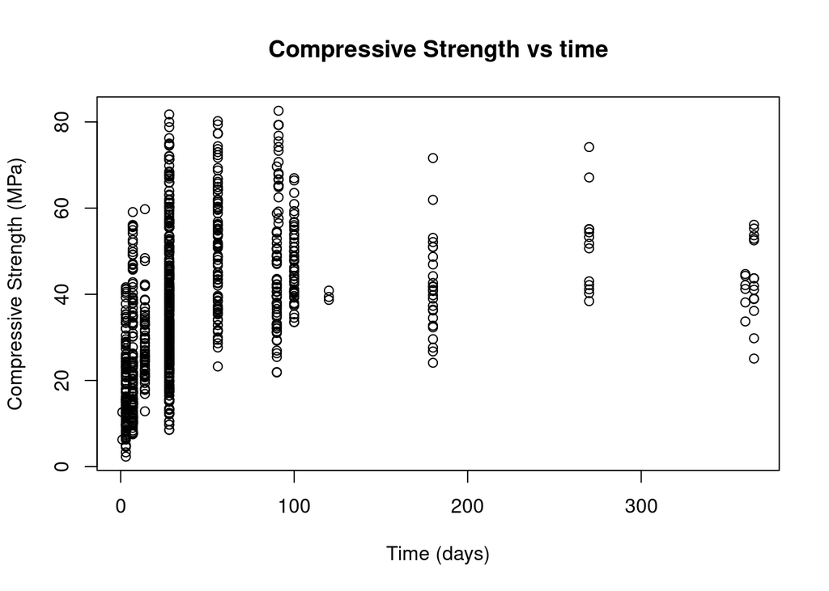

```r
library(ggplot2)
library(psych)
concrete_data<-read.csv("Concrete_Data.csv")
# To visualize the data. Make a scatter plot of Compressive strength vs time measured in days
x <- concrete_data$Age
y <- concrete_data$ConcreteCompressiveStrength

myplot <- plot.default(x, y, type="p", main = "Compressive Strength vs time", xlab = "Time (days)", ylab = "Compressive Strength (MPa)")
```

```r
png("myplot", width = 800, height = 600)
# The bulk of the samples were tested during the first 100 days.
# That is when the compressive strength reaches the stabilization of the logarithmic curve.

# perform PCA analysis
pca <- principal(concrete_data, nfactors = 8, rotate = "none")
pca
```

```
## Principal Components Analysis
## Call: principal(r = concrete_data, nfactors = 8, rotate = "none")
## Standardized loadings (pattern matrix) based upon correlation matrix
##                               PC1   PC2   PC3   PC4   PC5   PC6   PC7   PC8
## Cement                      -0.06  0.75  0.43 -0.32 -0.06 -0.36  0.07 -0.11
## BlastFurnaceSlag            -0.25  0.19 -0.83  0.08 -0.37  0.25  0.00 -0.09
## FlyAsh                       0.56 -0.37  0.02  0.61  0.23 -0.29 -0.13 -0.10
## Water                       -0.85 -0.16 -0.14  0.05  0.30 -0.28  0.01  0.22
## Superplasticizer             0.81  0.35 -0.22  0.17 -0.04 -0.08  0.33  0.17
## CoarseAggregate             -0.09 -0.31  0.65  0.23 -0.55  0.32  0.03  0.09
## FineAggregate                0.58 -0.26  0.00 -0.54  0.39  0.38 -0.09  0.05
## Age                         -0.40  0.35  0.20  0.37  0.53  0.47  0.18 -0.09
## ConcreteCompressiveStrength  0.16  0.88  0.04  0.23  0.00  0.14 -0.34  0.13
##                               h2      u2 com
## Cement                      0.99 6.4e-03 2.7
## BlastFurnaceSlag            0.99 5.9e-03 2.0
## FlyAsh                      1.00 4.3e-03 3.7
## Water                       1.00 3.6e-03 1.8
## Superplasticizer            1.00 8.0e-05 2.2
## CoarseAggregate             1.00 3.3e-03 3.4
## FineAggregate               0.99 5.0e-03 4.1
## Age                         1.00 4.5e-05 5.3
## ConcreteCompressiveStrength 1.00 1.1e-04 1.6
##
##                        PC1  PC2  PC3  PC4  PC5  PC6  PC7  PC8
## SS loadings           2.29 1.94 1.41 1.04 1.01 0.85 0.29 0.15
## Proportion Var        0.25 0.22 0.16 0.12 0.11 0.09 0.03 0.02
## Cumulative Var        0.25 0.47 0.63 0.74 0.85 0.95 0.98 1.00
## Proportion Explained  0.26 0.22 0.16 0.12 0.11 0.09 0.03 0.02
## Cumulative Proportion 0.26 0.47 0.63 0.74 0.86 0.95 0.98 1.00
##
## Mean item complexity =  3
## Test of the hypothesis that 8 components are sufficient.
##
## The root mean square of the residuals (RMSR) is  0
##  with the empirical chi square  0.7  with prob <  NA
##
## Fit based upon off diagonal values = 1
```

```r
# print the summary of PCA analysis
summary(pca)
```

```
##
## Factor analysis with Call: principal(r = concrete_data, nfactors = 8, rotate = "none")
##
## Test of the hypothesis that 8 factors are sufficient.
## The degrees of freedom for the model is -8  and the objective function was  3.02
## The number of observations was  1030  with Chi Square =  3080.4  with prob <  NA
##
## The root mean square of the residuals (RMSA) is  0
```

Then realized that more than finding patterns, I wanted to make predictions. So, I switched to a Linear Regression Model.

```r
library(shiny)
library(readr)
library(caret)
# Read CSV file
concrete_data<-read.csv("Concrete_Data.csv")

# Train model
set.seed(123)
trainIndex <- createDataPartition(concrete_data$ConcreteCompressiveStrength, p = 0.7, list = FALSE)
training <- concrete_data[trainIndex, ]
testing <- concrete_data[-trainIndex, ]
model <- train(as.formula("ConcreteCompressiveStrength ~ ."), method = "lm", data = training)
```

In this last chunk of code, the model takes a pieces of the data file for training purposes, 70% of the data. The remaining of the data was separated for testing purposes. On the line where model is defined, the method of chooice was linear model.

The stress-strain curve for concrete is linear only in the elastic part of the curve. This is the region where if you release the applied force, the material will recover form the deformation caused by the force. Where this analysis gets tricky is where the plastic part of the curve kicks in. This is the region where if the applied force is removed from the sample, the material will not be able to fully recover from the deformation caused by the force. This part of the curve is not linear.

When I look deeper, I realized that the data set only provides information on stress, not strain. Without strain values, it is not possible to make an accurate model of concrete behavior.

An option to make the current model more accurate, would be to limit its use to the elastic behavior exclusively. That reasoning poses a big problem into its application because the point where a mix design reaches the yield point, (which where the behavior changes from elastic to plastic), is not the same for every sample.